# Ex25 ficus

PIE2

Tardor 2019-2020

####Tenim l’alçada (H) de plantes de ficus i el nombre de dies des de que es van plantar (DIES) al fitxer ficus.csv. Sabem que $E\left[H|DIES\right]=e^{\alpha+\beta\cdot DIES}.$

####És un exemple en la recta no ajusta bé les dades i tant la regressió no lineal com la regressió amb la variable aleatòria transformada pel logaritme, no compleixe la homoscedasticitat. En el tema models lineals generalitzats resoldrem aquest problema.

####En tot l’exercici utilitzarem el nivell de significació $\alpha=0.05$ ####i treballarem els 4 models lineals següents :

####En cadascun d’aquest models ens centrarem en: • Analitzar si el model ajusta bé. • Veure si els residuals tenen variància constant o no. • En predir l’alçada en el moment de plantar els ficus, als 105 dies – i també al cap de 150 dies de la plantació.

*Directori de treball, paquets de R, llegir dades, descriptiva*

```r
#setwd("...")
dd<-read.csv2("../data/ficus.csv")
library(RcmdrMisc)
library(tables)
head(dd)
```

```
##   DIES   H
## 1    4 6.5
## 2    4 4.3
## 3    4 3.9
## 4    4 4.6
## 5    4 1.5
## 6    4 5.7
```

```r
#DESCRIPTIVA

cv<-function(x) {sd(x)/mean(x)}
di<-function(x) {var(x)/mean(x)}
(t<-tabular((DIES=as.factor(DIES))~H*((n.dades=1)+(mitjana=mean)+(desv.tipus=sd)+(coef.variació=cv)+(index.disp.=di)),dd))
```

| DIES | H n.dades | H mitjana | H desv.tipus | H coef.variació | H index.disp. |
| --- | --- | --- | --- | --- | --- |
| 4 | 30 | 4.573 | 1.355 | 0.2962 | 0.4013 |
| 23 | 30 | 7.817 | 1.943 | 0.2485 | 0.4829 |
| 39 | 30 | 9.250 | 2.819 | 0.3047 | 0.8588 |
| 58 | 30 | 12.983 | 3.433 | 0.2644 | 0.9075 |
| 73 | 30 | 15.237 | 3.308 | 0.2171 | 0.7181 |
| 90 | 30 | 22.060 | 3.916 | 0.1775 | 0.6953 |
| 108 | 30 | 29.823 | 3.966 | 0.1330 | 0.5274 |
| 126 | 30 | 39.773 | 3.651 | 0.0918 | 0.3352 |

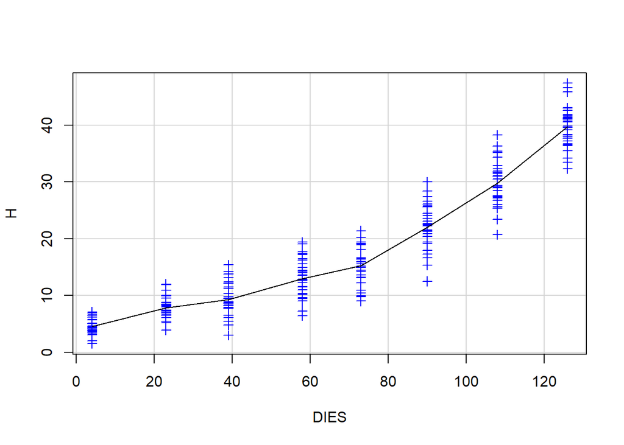

```r
scatterplot(H~DIES, regLine=F, smooth=F, boxplots=F,pch=3, data=dd)
lines(rowLabels(t),t[,2])
```

#___________________________________________________________________________________________

####Model A. La recta de regressió de H respecte DIES, $E\left[H|DIES\right]=\alpha+\beta\cdot DIES$ i $Var\left(H|DIES\right)=\sigma^{2}$.

**a) Ajusteu les dades amb la regressió lineal (o no lineal) calculeu els paràmetres estimats.**

```r
summary(ma<-lm(H~DIES,dd))
```

```
##
## Call:
## lm(formula = H ~ DIES, data = dd)
##
## Residuals:
##      Min       1Q   Median       3Q      Max
## -12.0236  -3.0257  -0.0164   3.2864  12.9860
##
## Coefficients:
##              Estimate Std. Error t value Pr(>|t|)
## (Intercept) -0.202468   0.558805  -0.362    0.717
## DIES         0.274734   0.007338  37.442   <2e-16 ***
## ---
## Signif. codes:  0 '***' 0.001 '**' 0.01 '*' 0.05 '.' 0.1 ' ' 1
##
## Residual standard error: 4.488 on 238 degrees of freedom
## Multiple R-squared:  0.8549, Adjusted R-squared:  0.8543
## F-statistic:  1402 on 1 and 238 DF,  p-value: < 2.2e-16
```

**b) Feu l’anàlisi dels residus “residual vs predit” i només pels models lineals també del dels “residuals studentitzats”.**

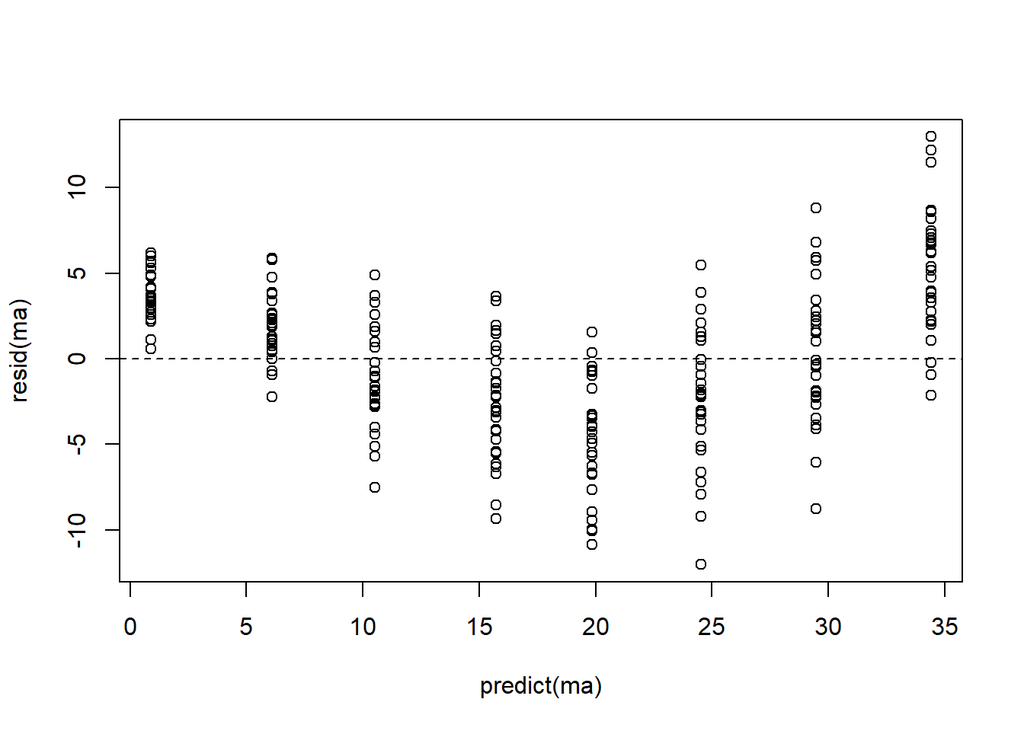

```r
plot(predict(ma),resid(ma))
abline(h=0,lt=2)
```

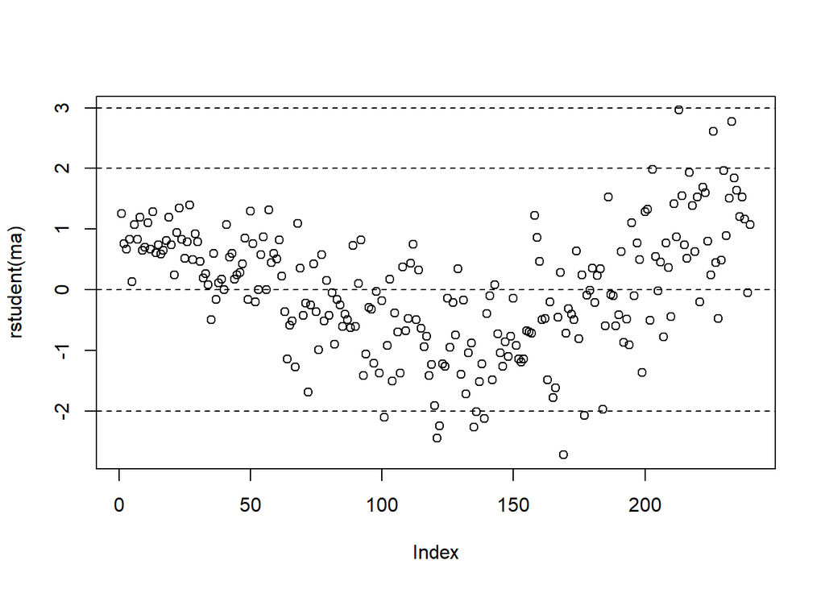

```r
plot(rstudent(ma))
abline(h=c(-3,-2,0,2,3),lt=2)
```

**c) Una característica de les dades d’aquest exemple és que hi ha moltes dades per a cadascun dels valors de la variable DIES, amb el que també es podria utilitzar DIES com a factor (FDIES). Així amb l’Anova del model YDIES+FDIES podrem determinar si afegir el factor FDIES millora el model o no. Nota: Pel model no lineal no contrasteu aquesta pregunta.**

```r
dd$FDIES<-as.factor(dd$DIES)
maf<-lm(H~DIES+FDIES,dd)
anova(ma,maf)
```

```
## Analysis of Variance Table
##
## Model 1: H ~ DIES
## Model 2: H ~ DIES + FDIES
##   Res.Df    RSS Df Sum of Sq      F    Pr(>F)
## 1    238 4793.2
## 2    232 2339.6  6    2453.6 40.551 < 2.2e-16 ***
## ---
## Signif. codes:  0 '***' 0.001 '**' 0.01 '*' 0.05 '.' 0.1 ' ' 1
```

**d) Per la mateixa característica anterior, es pot estudiar l’homoscedasticitat dels residuals amb el test de levene (leveneTest(…)). Utilitzant aquest test dieu si hi ha homoscedasticitat o no.**

```r
leveneTest(resid(ma),dd$FDIES)
```

```
## Levene's Test for Homogeneity of Variance (center = median)
##        Df F value    Pr(>F)
## group   7  4.5649 8.526e-05 ***
##       232
## ---
## Signif. codes:  0 '***' 0.001 '**' 0.01 '*' 0.05 '.' 0.1 ' ' 1
```

**e) Calculeu la regió de predicció de H en els (models lineals), en els DIES={ 0,105,150}.**

```r
predict(ma,data.frame(DIES=c(0,105,150)),interval="prediction")
```

```
##          fit       lwr       upr
## 1 -0.2024676 -9.111461  8.706526
## 2 28.6446011 19.766752 37.522450
## 3 41.0076305 32.063965 49.951296
```

#___________________________________________________________________________________________

####Mod B. Amb la funció de regressió la paràbola de H respecte DIES ja que la podem considerar una aproximació a la funció exponencial. $E\left[H|DIES\right]=\alpha+\beta\cdot DIES+\gamma\cdot DIES^{2}$ i $Var\left(H|DIES\right)=\sigma^{2}$.

**a) Ajusteu les dades amb la regressió lineal (o no lineal) calculeu els paràmetres estimats.**

```r
dd$DIES2<-dd$DIES^2
summary(mb<-lm(H~DIES+DIES2,dd))
```

```
##
## Call:
## lm(formula = H ~ DIES + DIES2, data = dd)
##
## Residuals:
##     Min      1Q  Median      3Q     Max
## -9.9578 -2.0628 -0.0578  2.0450  8.2450
##
## Coefficients:
##               Estimate Std. Error t value Pr(>|t|)
## (Intercept)  5.6949955  0.5716569   9.962   <2e-16 ***
## DIES        -0.0120001  0.0202915  -0.591    0.555
## DIES2        0.0022028  0.0001504  14.645   <2e-16 ***
## ---
## Signif. codes:  0 '***' 0.001 '**' 0.01 '*' 0.05 '.' 0.1 ' ' 1
##
## Residual standard error: 3.258 on 237 degrees of freedom
## Multiple R-squared:  0.9238, Adjusted R-squared:  0.9232
## F-statistic:  1437 on 2 and 237 DF,  p-value: < 2.2e-16
```

**b) Feu l’anàlisi dels residus “residual vs predit” i només pels models lineals també del dels “residuals studentitzats”.**

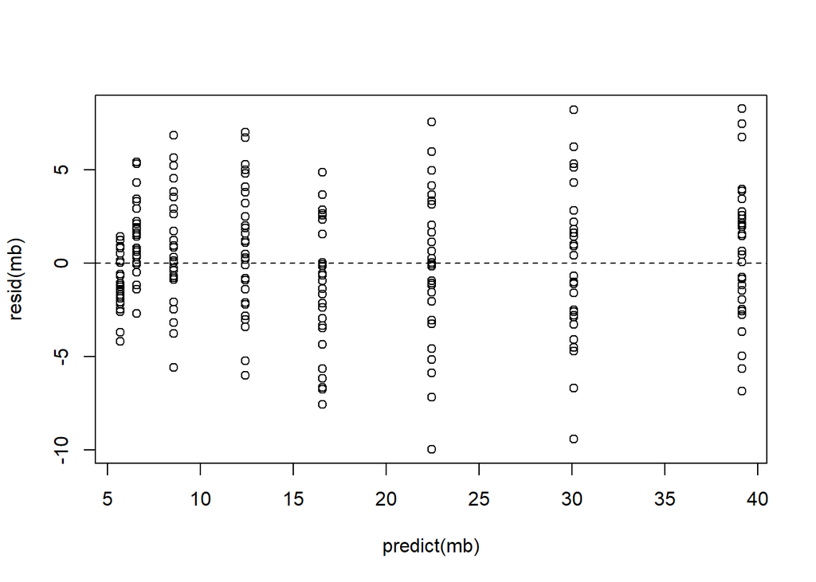

```r
plot(predict(mb),resid(mb))
abline(h=0,lt=2)
```

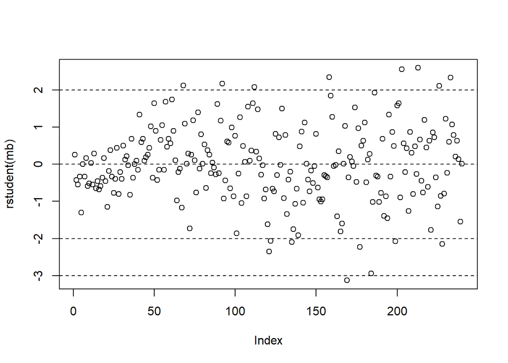

```r
plot(rstudent(mb))
abline(h=c(-3,-2,0,2,3),lt=2)
```

**c) Una característica de les dades d’aquest exemple és que hi ha moltes dades per a cadascun dels valors de la variable DIES, amb el que també es podria utilitzar DIES com a factor (FDIES). Així amb l’Anova del model YDIES+FDIES podrem determinar si afegir el factor FDIES millora el model o no. Nota: Pel model no lineal no contrasteu aquesta pregunta.**

```r
dd$FDIES<-as.factor(dd$DIES)
mbf<-lm(H~DIES+DIES2+FDIES,dd)
anova(mb,mbf)
```

```
## Analysis of Variance Table
##
## Model 1: H ~ DIES + DIES2
## Model 2: H ~ DIES + DIES2 + FDIES
##   Res.Df    RSS Df Sum of Sq      F   Pr(>F)
## 1    237 2516.3
## 2    232 2339.6  5    176.67 3.5038 0.004505 **
## ---
## Signif. codes:  0 '***' 0.001 '**' 0.01 '*' 0.05 '.' 0.1 ' ' 1
```

**d) Per la mateixa característica anterior, es pot estudiar l’homoscedasticitat dels residuals amb el test de levene (leveneTest(…)). Utilitzant aquest test dieu si hi ha homoscedasticitat o no.**

```r
leveneTest(resid(mb),dd$FDIES)
```

```
## Levene's Test for Homogeneity of Variance (center = median)
##        Df F value    Pr(>F)
## group   7  4.5649 8.526e-05 ***
##       232
## ---
## Signif. codes:  0 '***' 0.001 '**' 0.01 '*' 0.05 '.' 0.1 ' ' 1
```

**e) Calculeu la regió de predicció de H en els (models lineals), en els DIES={ 0,105,150}.**

```r
predict(mb,data.frame(DIES=c(0,105,150),DIES2=c(0,105,150)^2),interval="prediction")
```

```
##         fit        lwr      upr
## 1  5.694996 -0.8221567 12.21215
## 2 28.721102 22.2750224 35.16718
## 3 53.458484 46.7521003 60.16487
```

#___________________________________________________________________________________________

####Mod C. La recta de regressió de log(H) respecte DIES, ja que la transformació *log* homogeneitza les variàncies quan $Var\propto\mu^{2}$ encara que l’important en aquest cas és que linealitza la funció $e^{\alpha+\beta\cdot DIES}$. $E\left[log\left(H\right)|DIES\right]=\alpha+\beta\cdot DIES$ i $Var\left(log\left(H\right)|DIES\right)=\sigma^{2}.$

**a) Ajusteu les dades amb la regressió lineal (o no lineal) calculeu els paràmetres estimats.**

```r
summary(mc<-lm(log(H)~DIES,dd))
```

```
##
## Call:
## lm(formula = log(H) ~ DIES, data = dd)
##
## Residuals:
##      Min       1Q   Median       3Q      Max
## -1.16093 -0.10819  0.00545  0.16146  0.58792
##
## Coefficients:
##              Estimate Std. Error t value Pr(>|t|)
## (Intercept) 1.4968002  0.0314308   47.62   <2e-16 ***
## DIES        0.0173996  0.0004127   42.16   <2e-16 ***
## ---
## Signif. codes:  0 '***' 0.001 '**' 0.01 '*' 0.05 '.' 0.1 ' ' 1
##
## Residual standard error: 0.2524 on 238 degrees of freedom
## Multiple R-squared:  0.8819, Adjusted R-squared:  0.8814
## F-statistic:  1777 on 1 and 238 DF,  p-value: < 2.2e-16
```

**b) Feu l’anàlisi dels residus “residual vs predit” i només pels models lineals també del dels “residuals studentitzats”.**

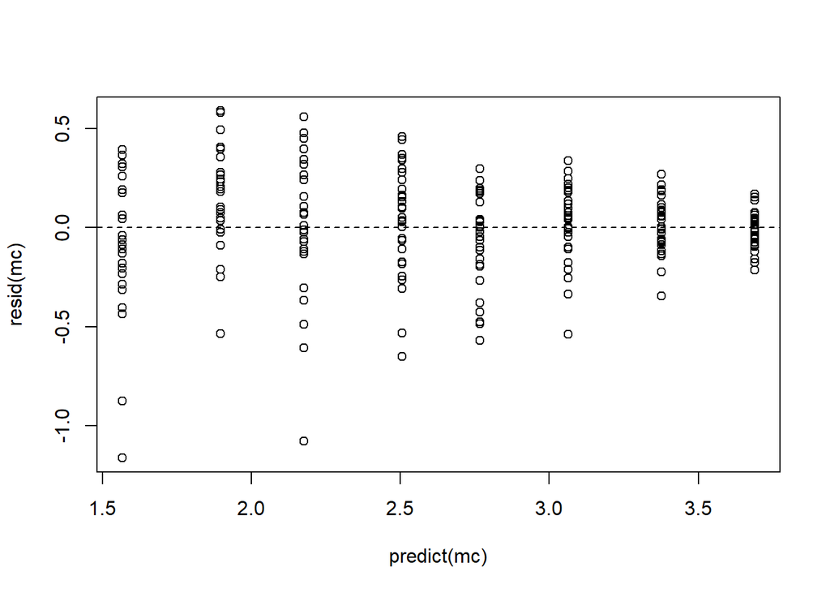

```r
plot(predict(mc),resid(mc))
abline(h=0,lt=2)
```

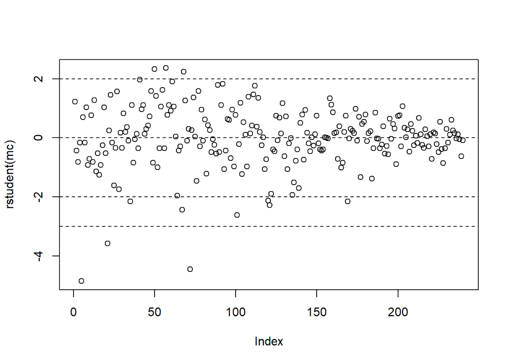

```r
plot(rstudent(mc))
abline(h=c(-3,-2,0,2,3),lt=2)
```

**c) Una característica de les dades d’aquest exemple és que hi ha moltes dades per a cadascun dels valors de la variable DIES, amb el que també es podria utilitzar DIES com a factor (FDIES). Així amb l’Anova del model YDIES+FDIES podrem determinar si afegir el factor FDIES millora el model o no. Nota: Pel model no lineal no contrasteu aquesta pregunta.**

```r
dd$FDIES<-as.factor(dd$DIES)
mcf<-lm(log(H)~DIES+FDIES,dd)
anova(mc,mcf)
```

```
## Analysis of Variance Table
##
## Model 1: log(H) ~ DIES
## Model 2: log(H) ~ DIES + FDIES
##   Res.Df    RSS Df Sum of Sq      F Pr(>F)
## 1    238 15.164
## 2    232 14.228  6   0.93593 2.5435  0.021 *
## ---
## Signif. codes:  0 '***' 0.001 '**' 0.01 '*' 0.05 '.' 0.1 ' ' 1
```

**d) Per la mateixa característica anterior, es pot estudiar l’homoscedasticitat dels residuals amb el test de levene (leveneTest(…)). Utilitzant aquest test dieu si hi ha homoscedasticitat o no.**

```r
leveneTest(resid(mc),dd$FDIES)
```

```
## Levene's Test for Homogeneity of Variance (center = median)
##        Df F value    Pr(>F)
## group   7  4.3801 0.0001385 ***
##       232
## ---
## Signif. codes:  0 '***' 0.001 '**' 0.01 '*' 0.05 '.' 0.1 ' ' 1
```

**e) Calculeu la regió de predicció de H en els (models lineals), en els DIES={ 0,105,150}.**

```r
exp(predict(mc,data.frame(DIES=c(0,105,150)),interval="prediction"))
```

```
##         fit       lwr        upr
## 1  4.467372  2.706622   7.373548
## 2 27.764570 16.851062  45.746157
## 3 60.748587 36.733709 100.463332
```

#___________________________________________________________________________________________

####Mod D. La recta de regressió de $\sqrt{H}$ respecte DIES, ja que la transformació $\sqrt{}$ homogeneitza les variàncies quan $Var\propto\mu$. $E\left[sqrt\left(H\right)|DIES\right]=\alpha+\beta\cdot DIES$ i $Var\left(\left(H\right)|DIES\right)=\sigma^{2}.$

**a) Ajusteu les dades amb la regressió lineal (o no lineal) calculeu els paràmetres estimats.**

```r
summary(md<-lm(sqrt(H)~DIES,dd))
```

```
##
## Call:
## lm(formula = sqrt(H) ~ DIES, data = dd)
##
## Residuals:
##      Min       1Q   Median       3Q      Max
## -1.37196 -0.24173  0.02998  0.31594  0.89178
##
## Coefficients:
##              Estimate Std. Error t value Pr(>|t|)
## (Intercept) 1.8089590  0.0556179   32.52   <2e-16 ***
## DIES        0.0332066  0.0007303   45.47   <2e-16 ***
## ---
## Signif. codes:  0 '***' 0.001 '**' 0.01 '*' 0.05 '.' 0.1 ' ' 1
##
## Residual standard error: 0.4467 on 238 degrees of freedom
## Multiple R-squared:  0.8968, Adjusted R-squared:  0.8963
## F-statistic:  2067 on 1 and 238 DF,  p-value: < 2.2e-16
```

**b) Feu l’anàlisi dels residus “residual vs predit” i només pels models lineals també del dels “residuals studentitzats”.**

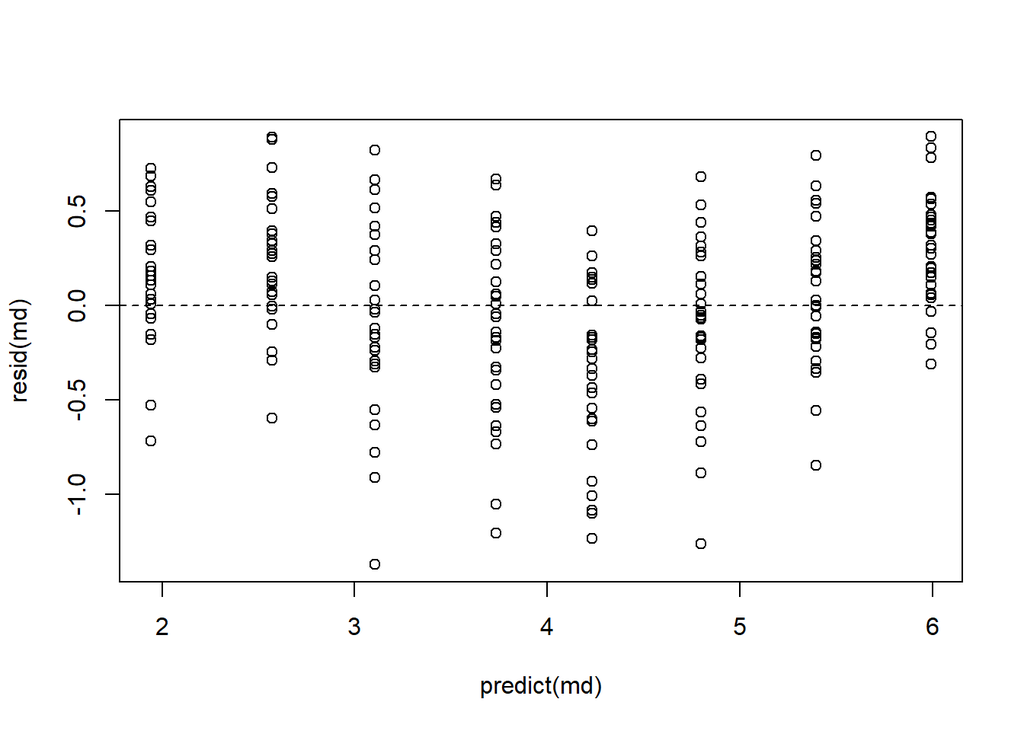

```r
plot(predict(md),resid(md))
abline(h=0,lt=2)
```

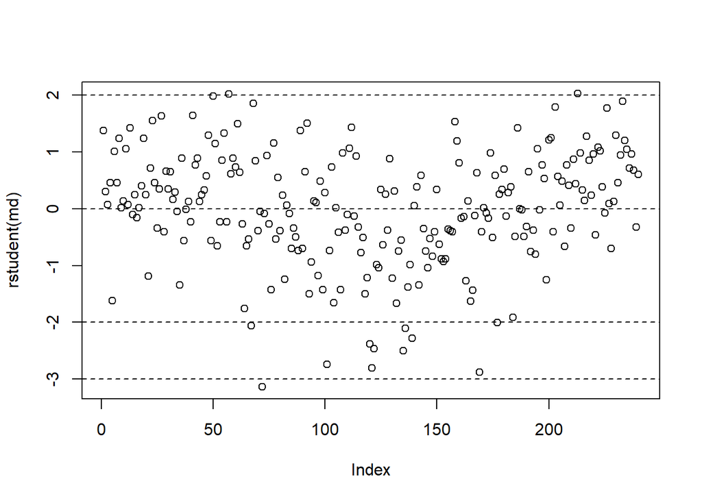

```r
plot(rstudent(md))
abline(h=c(-3,-2,0,2,3),lt=2)
```

**c) Una característica de les dades d’aquest exemple és que hi ha moltes dades per a cadascun dels valors de la variable DIES, amb el que també es podria utilitzar DIES com a factor (FDIES). Així amb l’Anova del model YDIES+FDIES podrem determinar si afegir el factor FDIES millora el model o no. Nota: Pel model no lineal no contrasteu aquesta pregunta.**

```r
dd$FDIES<-as.factor(dd$DIES)
mdf<-lm(sqrt(H)~DIES+FDIES,dd)
anova(ma,maf)
```

```
## Analysis of Variance Table
##
## Model 1: H ~ DIES
## Model 2: H ~ DIES + FDIES
##   Res.Df    RSS Df Sum of Sq      F    Pr(>F)
## 1    238 4793.2
## 2    232 2339.6  6    2453.6 40.551 < 2.2e-16 ***
## ---
## Signif. codes:  0 '***' 0.001 '**' 0.01 '*' 0.05 '.' 0.1 ' ' 1
```

**d) Per la mateixa característica anterior, es pot estudiar l’homoscedasticitat dels residuals amb el test de levene (leveneTest(…)). Utilitzant aquest test dieu si hi ha homoscedasticitat o no.**

```r
leveneTest(resid(md),dd$FDIES)
```

```
## Levene's Test for Homogeneity of Variance (center = median)
##        Df F value Pr(>F)
## group   7  1.4751  0.177
##       232
```

**e) Calculeu la regió de predicció de H en els (models lineals), en els DIES={ 0,105,150}.**

```r
(predict(md,data.frame(DIES=c(0,105,150)),interval="prediction"))^2
```

```
##         fit        lwr       upr
## 1  3.272333  0.8505405  7.266639
## 2 28.043883 19.4660601 38.183244
## 3 46.103321 34.8074063 58.984013
```

#___________________________________________________________________________________________

####Per tots 4 models:

**f) Compareu els models entre ells**

```r
rbind("logLik"=c("Model A"=logLik(ma),"Model B"=logLik(mb),"Model C"=logLik(mc),"Model D"=logLik(md)),
"AIC"=c(AIC(ma),AIC(mb),AIC(mc),AIC(md)),
"BIC"=c(BIC(ma),BIC(mb),BIC(mc),BIC(md)),
"R2"=c(summary(ma)$adj.r.squared,summary(mb)$adj.r.squared,summary(mc)$adj.r.squared,summary(md)$adj.r.squared))
```

```
##             Model A      Model B    Model C      Model D
## logLik -699.8636454 -622.5319643 -9.1404594 -146.1123925
## AIC    1405.7272908 1253.0639286 24.2809189  298.2247850
## BIC    1416.1692076 1266.9864843 34.7228356  308.6667018
## R2        0.8542609    0.9231698  0.8814138    0.8963332
```

**i feu les gràfiques de les dades amb les bandes de predicció.**

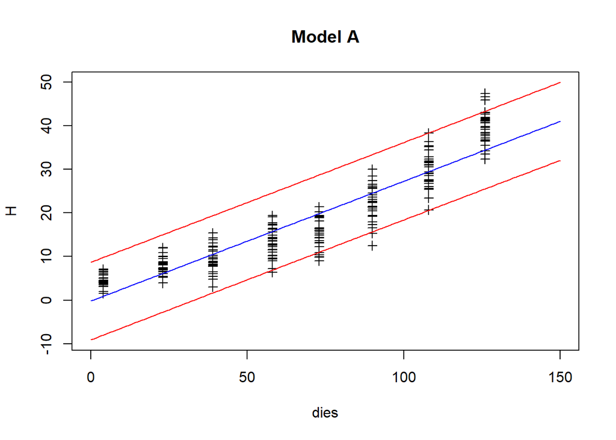

```r
dies=0:150
pra<-predict(ma,data.frame(DIES=dies),interval="prediction")
prb<-predict(mb,data.frame(DIES=dies,DIES2=dies^2),interval="prediction")
prc<-predict(mc,data.frame(DIES=dies),interval="prediction")
prd<-predict(md,data.frame(DIES=dies),interval="prediction")

#oldpar <- par( mfrow=c(2,2))

plot(dd$DIES,dd$H,pch=3,xlim=c(0,150),xlab="dies",ylab="H",ylim=c(min(dd$H,pra),max(dd$H,pra)),main="Model A")
lines(dies,pra[,"fit"],col="blue")
lines(dies,pra[,"lwr"],col="red")
lines(dies,pra[,"upr"],col="red")
```

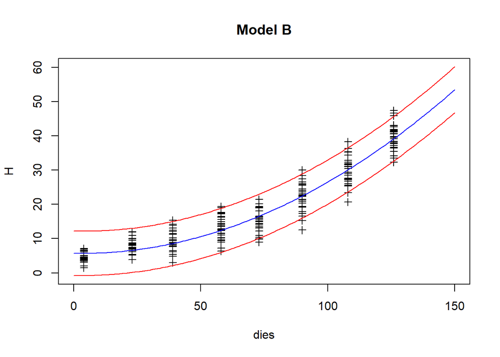

```r
plot(dd$DIES,dd$H,pch=3,xlim=c(0,150),xlab="dies",ylab="H",ylim=c(min(dd$H,prb),max(dd$H,prb)),main="Model B")
lines(dies,prb[,"fit"],col="blue")
lines(dies,prb[,"lwr"],col="red")
lines(dies,prb[,"upr"],col="red")
```

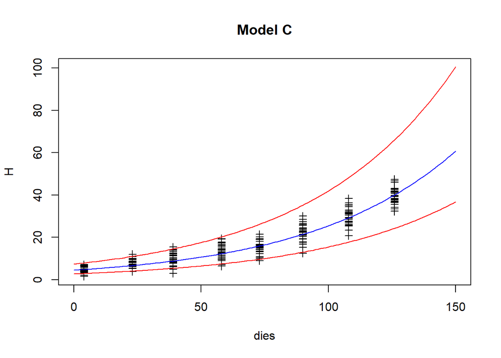

```r
plot(dd$DIES,dd$H,pch=3,xlim=c(0,150),xlab="dies",ylab="H",ylim=c(min(dd$H,exp(prc)),max(dd$H,exp(prc))),main="Model C")
lines(dies,exp(prc[,"fit"]),col="blue")
lines(dies,exp(prc[,"lwr"]),col="red")
lines(dies,exp(prc[,"upr"]),col="red")
```

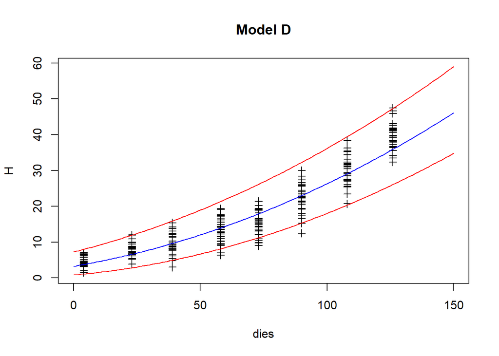

```r
plot(dd$DIES,dd$H,pch=3,xlim=c(0,150),xlab="dies",ylab="H",ylim=c(min(dd$H,prd^2),max(dd$H,prd^2)),main="Model D")
lines(dies,prd[,"fit"]^2,col="blue")
lines(dies,prd[,"lwr"]^2,col="red")
lines(dies,prd[,"upr"]^2,col="red")
```

```r
#par(oldpar)
```